# Patient Medication Adherence Prediction

The patient medication adherence classification project is a critical endeavor in healthcare aimed at predicting and categorizing patients’ adherence to prescribed medications. Leveraging a dataset that includes variables such as patient age, prescription duration, medical conditions like diabetes and hypertension, lifestyle factors like smoking and alcoholism, and SMS reminders, the project seeks to develop a robust model for patient classification. By accurately distinguishing between adherent and non-adherent patients, healthcare providers can tailor interventions and support to enhance medication compliance, ultimately improving patient outcomes and reducing healthcare costs. This project represents a significant step toward more effective patient-centered care and better healthcare management.

# **Loading dataset**

### Loading dataset path

```r
file_path <- "D:/College/Assignments/Semester 5/Theory/Introduction to Data Science/dataset.csv"
```

### Loading dataset

```r
data <- read.csv(file_path)
```

# **Exploratory Data Analysis**

### Analyzing Dimensions of data

```r
dim(data)
```

```
[1] 180212     11
```

The dataset has 180212 rows and 11 columns

### Visualizing first few rows of data

```r
head(data)
```

|  | patient_id | Age | Gender | Prescription_period | Diabetes | Alcoholism | HyperTension | Smokes | Tuberculosis | Sms_Reminder | Adherence |
| --- | --- | --- | --- | --- | --- | --- | --- | --- | --- | --- | --- |
| 1 | 1 | 19 | M | 7 | 0 | 0 | 0 | 0 | 0 | 0 | No |
| 2 | 2 | 24 | F | 59 | 0 | 0 | 0 | 0 | 0 | 0 | No |
| 3 | 3 | 4 | F | 43 | 0 | 0 | 0 | 0 | 0 | 0 | No |
| 4 | 4 | 38 | M | 66 | 0 | 0 | 0 | 0 | 0 | 1 | No |
| 5 | 5 | 46 | F | 98 | 0 | 0 | 0 | 0 | 0 | 1 | No |
| 6 | 6 | 20 | F | 73 | 0 | 0 | 0 | 0 | 0 | 0 | No |

Adherence is the target variable. Others columns are thefeatures.

### Visualizing structure of data as R object

```r
str(data)
```

```
'data.frame':   180212 obs. of  11 variables:
 $ patient_id         : int  1 2 3 4 5 6 7 8 9 10 ...
 $ Age                : int  19 24 4 38 46 20 51 58 73 48 ...
 $ Gender             : chr  "M" "F" "F" "M" ...
 $ Prescription_period: int  7 59 43 66 98 73 102 96 89 97 ...
 $ Diabetes           : int  0 0 0 0 0 0 1 0 0 0 ...
 $ Alcoholism         : int  0 0 0 0 0 0 0 0 0 0 ...
 $ HyperTension       : int  0 0 0 0 0 0 1 1 1 0 ...
 $ Smokes             : int  0 0 0 0 0 0 0 0 0 0 ...
 $ Tuberculosis       : int  0 0 0 0 0 0 0 0 0 0 ...
 $ Sms_Reminder       : int  0 0 0 1 1 0 1 1 0 1 ...
 $ Adherence          : chr  "No" "No" "No" "No" ...
```

### Summary structure of data

```r
summary(data)
```

```
   patient_id          Age           Gender          Prescription_period    Diabetes         Alcoholism
 Min.   :     1   Min.   :  0.0   Length:180212      Min.   :  1.00      Min.   :0.00000   Min.   :0.00000
 1st Qu.: 45054   1st Qu.: 19.0   Class :character   1st Qu.: 22.00      1st Qu.:0.00000   1st Qu.:0.00000
 Median : 90107   Median : 38.0   Mode  :character   Median : 51.00      Median :0.00000   Median :0.00000
 Mean   : 90107   Mean   : 37.8                      Mean   : 54.67      Mean   :0.07852   Mean   :0.02504
 3rd Qu.:135159   3rd Qu.: 56.0                      3rd Qu.: 86.00      3rd Qu.:0.00000   3rd Qu.:0.00000
 Max.   :180212   Max.   :113.0                      Max.   :120.00      Max.   :1.00000   Max.   :1.00000
  HyperTension        Smokes         Tuberculosis        Sms_Reminder    Adherence
 Min.   :0.0000   Min.   :0.00000   Min.   :0.0000000   Min.   :0.000   Length:180212
 1st Qu.:0.0000   1st Qu.:0.00000   1st Qu.:0.0000000   1st Qu.:0.000   Class :character
 Median :0.0000   Median :0.00000   Median :0.0000000   Median :1.000   Mode  :character
 Mean   :0.2165   Mean   :0.05257   Mean   :0.0003385   Mean   :0.574
 3rd Qu.:0.0000   3rd Qu.:0.00000   3rd Qu.:0.0000000   3rd Qu.:1.000
 Max.   :1.0000   Max.   :1.00000   Max.   :1.0000000   Max.   :2.000
```

### Calculating number of null values in data

```r
colSums(is.na(data))
```

```
         patient_id                 Age              Gender Prescription_period            Diabetes
                  0                   0                   0                   0                   0
         Alcoholism        HyperTension              Smokes        Tuberculosis        Sms_Reminder
                  0                   0                   0                   0                   0
          Adherence
                  0
```

The data has no null values.

### Loading psych library

```r
library(psych)
```

### Description of data

```r
describe(data)
```

|  | vars | n | mean | sd | median | trimmed | mad | min | max | range | skew | kurtosis | se |
| --- | --- | --- | --- | --- | --- | --- | --- | --- | --- | --- | --- | --- | --- |
| patient_id | 1 | 180212 | 90106.50 | 52022.87 | 90106.5 | 90106.50 | 66795.58 | 1 | 180212 | 180211 | 0.00 | -1.20 | 122.55 |
| Age | 2 | 180212 | 37.80 | 22.85 | 38.0 | 37.43 | 26.69 | 0 | 113 | 113 | 0.08 | -0.95 | 0.05 |
| Gender* | 3 | 180212 | 1.33 | 0.47 | 1.0 | 1.29 | 0.00 | 1 | 2 | 1 | 0.71 | -1.49 | 0.00 |
| Prescription_period | 4 | 180212 | 54.67 | 35.75 | 51.0 | 53.52 | 45.96 | 1 | 120 | 119 | 0.22 | -1.25 | 0.08 |
| Diabetes | 5 | 180212 | 0.08 | 0.27 | 0.0 | 0.00 | 0.00 | 0 | 1 | 1 | 3.13 | 7.82 | 0.00 |
| Alcoholism | 6 | 180212 | 0.03 | 0.16 | 0.0 | 0.00 | 0.00 | 0 | 1 | 1 | 6.08 | 34.96 | 0.00 |
| HyperTension | 7 | 180212 | 0.22 | 0.41 | 0.0 | 0.15 | 0.00 | 0 | 1 | 1 | 1.38 | -0.11 | 0.00 |
| Smokes | 8 | 180212 | 0.05 | 0.22 | 0.0 | 0.00 | 0.00 | 0 | 1 | 1 | 4.01 | 14.08 | 0.00 |
| Tuberculosis | 9 | 180212 | 0.00 | 0.02 | 0.0 | 0.00 | 0.00 | 0 | 1 | 1 | 54.33 | 2949.26 | 0.00 |
| Sms_Reminder | 10 | 180212 | 0.57 | 0.50 | 1.0 | 0.59 | 0.00 | 0 | 2 | 2 | -0.24 | -1.78 | 0.00 |

[output cut: 1 more lines]

# **Data Visualization**

### Visualizing category wise frequency of target variable Adherence

```r
# Calculate the category wise frequency of Adherence values
temp <- table(data$Adherence)
temp
```

```
    No    Yes
125822  54390
```

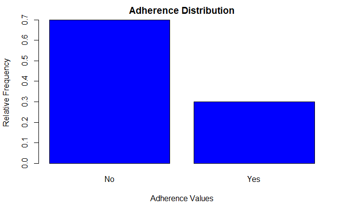

```r
# Calculate the relative frequencies
relative_frequencies <- round(prop.table(temp), 2)

# Create a bar plot
barplot(relative_frequencies,
        names.arg = names(temp),
        col = "blue",
        main = "Adherence Distribution",
        xlab = "Adherence Values",
        ylab = "Relative Frequency")
```

```r
NA
NA
```

The target class exhibits an imbalance, and sampling techniques will not be utilized. Given that the primary focus in the medical field is on precision and recall, accuracy is not the sole determinant of performance.

### Visualizing category wise frequency of feature Gender

```r
# Print the size of each group
table(data$Gender)
```

```
     F      M
120438  59774
```

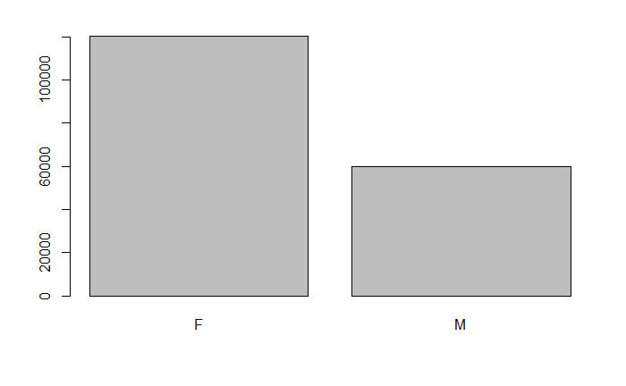

```r
# Create a count plot
barplot(table(data$Gender), names.arg = names(table(data$Gender)))
```

### Visualizing category wise frequency of feature Diabetes

```r
# Print the size of each group
table(data$Diabetes)
```

```
     0      1
166061  14151
```

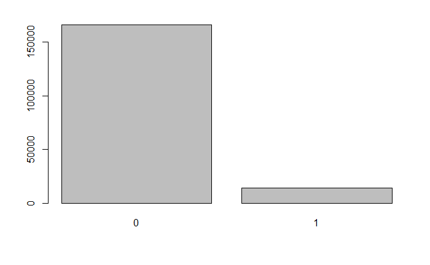

```r
# Create a count plot
barplot(table(data$Diabetes), names.arg = names(table(data$Diabetes)))
```

### Visualizing category wise frequency of feature Alcoholism

```r
# Print the size of each group
table(data$Alcoholism)
```

```
     0      1
175699   4513
```

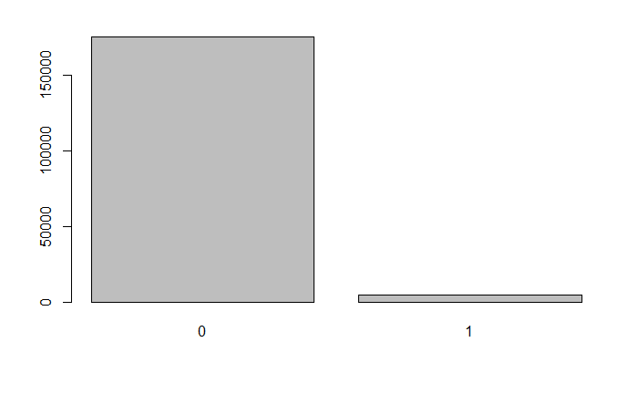

```r
# Create a count plot
barplot(table(data$Alcoholism), names.arg = names(table(data$Alcoholism)))
```

```r
# Print the size of each group
table(data$HyperTension)
```

```
     0      1
141194  39018
```

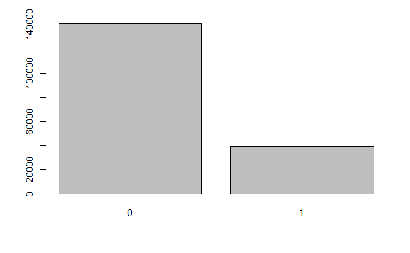

```r
# Create a count plot
barplot(table(data$HyperTension), names.arg = names(table(data$HyperTension)))
```

### Visualizing category wise frequency of feature Tuberculosis

```r
# Print the size of each group
table(data$Tuberculosis)
```

```
     0      1
180151     61
```

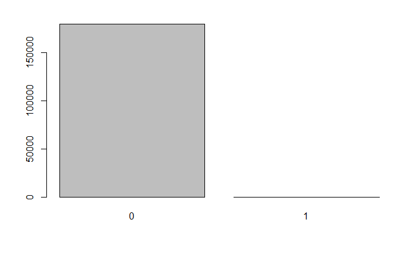

```r
# Create a count plot
barplot(table(data$Tuberculosis), names.arg = names(table(data$Tuberculosis)))
```

### Visualizing category wise frequency of feature Smokes

```r
# Print the size of each group
table(data$Smokes)
```

```
     0      1
170739   9473
```

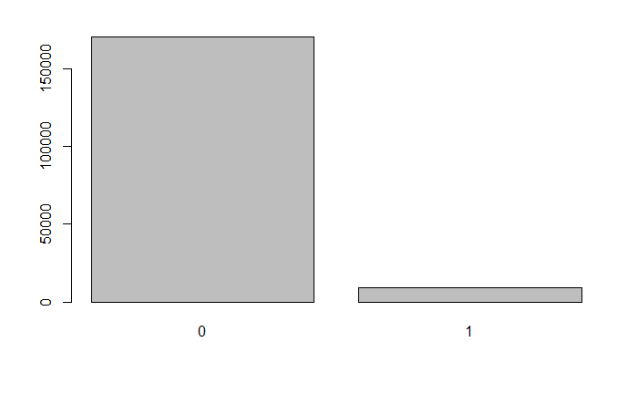

```r
# Create a count plot
barplot(table(data$Smokes), names.arg = names(table(data$Smokes)))
```

# **Multivriate Data Visualization**

### Genderwise Adherence

#### Tabular description

```r
# Use table() to count combinations of Gender and Adherence
gender_adherence_table <- table(data$Gender, data$Adherence)

# Convert the table to a data frame
Gender_Adherence <- as.data.frame(gender_adherence_table)

# Rename the columns
colnames(Gender_Adherence) <- c("Gender", "Adherence", "Count")

# Display the resulting data frame
Gender_Adherence
```

| Gender | Adherence | Count |
| --- | --- | --- |
| F | No | 84487 |
| M | No | 41335 |
| F | Yes | 35951 |
| M | Yes | 18439 |

```r
NA
```

#### Visualization

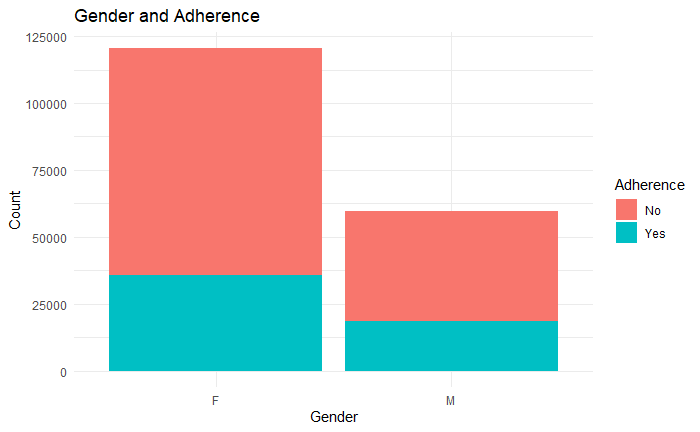

```r
# Load the ggplot2 library
library(ggplot2)
# Create a ggplot object
ggplot(data = Gender_Adherence, aes(x = Gender, y = Count, fill = Adherence)) +
  geom_bar(stat = "identity") +
  labs(title = "Gender and Adherence") +
  theme_minimal()
```

### Tuberculosis and Adherence

#### Tabular description

```r
# Create a table of counts
tuberculosis_adherence_table <- table(data$Tuberculosis, data$Adherence)

# Print the table
print(tuberculosis_adherence_table)
```

```
        No    Yes
  0 125783  54368
  1     39     22
```

#### Visualization

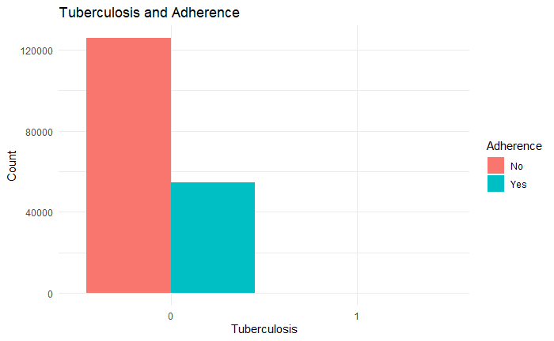

```r
tuberculosis_adherence_df <- as.data.frame(tuberculosis_adherence_table)

# Rename the columns
colnames(tuberculosis_adherence_df) <- c("Tuberculosis", "Adherence", "Count")

# Create a bar plot
ggplot(data = tuberculosis_adherence_df, aes(x = Tuberculosis, y = Count, fill = Adherence)) +
  geom_bar(stat = "identity", position = "dodge") +
  labs(title = "Tuberculosis and Adherence") +
  theme_minimal()
```

### Smokes and Adherence

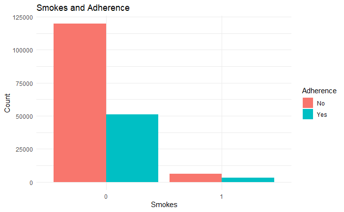

[figure not shown]

[figure not shown]

[figure not shown]

[figure not shown]